# ‘Buy on rumor, sell on news’: the effect of news arrivals and investor sentiment on the distribution of excess returns

Maria Osipenko[^1], Rui Ren[^2]

31 Oktober, 2022

# Abstract

We analyse how the distribution of excess returns is influenced by investor opinion as investor sentiment and news arrivals by applying the expectile regression to a panel of $100$ excess equity returns in NASDAQ over the period April 2015 - August 2019. We break down investor opinion in investor attention, perception and sentiment and use firm and time specific proxies as news arrivals and news sentiment computed by dictionary and machine learning methods for each of the channels.

We find, that various effects depend on the expectile level $\tau$, which itself can be understood as the ‘state of the world’ for individual equity returns. While not always significant for the mean regression, the proxies of investment opinion impact the conditional distribution of asset returns which we show empirically.

When analyzing the effect of news and earnings announcements, we find a positive impact of the day before earnings announcements and a negative impact of news arrivals on low return expectiles. We explain this effect with the strategy “buy on rumor, sell on news” for low return states.

Our expectile regression approach allows us to naturally generalize the previous studies of conditional mean regression to higher conditional moments and estimate investor opinion impact thereon. Moreover, by using the relation of expectiles to expected shortfall, we are able to obtain the effects of investor opinion on the conditional expected shortfall.

# Introduction

The effects of public information flow as news arrivals and investor sentiment on stock returns and the question whether they make up good predictors of the later have captured attention of many researches. However the results are somewhat fragmented and debatable. For instance, Antweiler and Frank (2004) find that the number and extent of text messages influences stock volatility but not returns. Das and Chen (2007) observe that the message volume (regarded as optimistic sentiment) is positively correlated with stock volatility but negatively correlated with stock returns. Hagenau, Liebmann, and Neumann (2013) and Nguyen, Shirai, and Velcin (2015) among others are able to significantly improve their return forecasts by using sentiment from news or social media. Shang, Brooks, and McCloy (2014) find a significant effect of sentiment only related to the negative announcements. Kim and Kim (2014) find no evidence for predictive power of sentiment neither on returns nor on volatility or trading volume. Recently, Audrino, Sigrist, and Ballinari (2020) and Fang et al. (2021) again report an improvement in volatility forecasts on using sentiment from news and social media.

Su, Qu, and Kang (2021) distinguish three channels, through which the information flow may influence asset returns: *investor perception* (expectations, risk perception and individual believes), captured by financial variables, event-related *investor attention* and *investor sentiment* usually specified as polarity of news and social media messages content.

In this paper we analyse the impact of the three information flow channels on the distribution of daily asset returns. Thereby we indicate *investor attention* using indicators of days around earnings announcements, news arrivals and share turnover. *Investor perception* is captured by book-to-market ratios, size and earnings surprises. Dictionary-based and machine learning polarity assessment of firm-specific news content measures are used as proxies of *investor sentiment*. Our choice of the proxies is based on the empirical evidence found in the previous literature, which we provide below.

Two important issues arise when analyzing the effects above. First, whereas some of the indicators as earnings announcements and news arrivals can be directly observed, investor sentiment is a latent variable and has to be inferred from news and social media messages. The later holds also for the investor perception channel. Second, although most empirical findings confirm significant effects, there is no consensus on which parameters of the conditional return distribution are affected (conditional expectation, variance or higher moments).

To model the impact on the conditional variance, typically GARCH-type models are employed. Campbell and Hentschel (1992) proposes such a model which incorporates an asymmetric news-about-dividends impact on return volatility. Further focusing on this effect and using broad firm specific news arrivals as a proxy for information flow Kalev et al. (2004) report significant effects on intraday and daily level. The authors write “when public news is released, market activity intensifies as a result of belief revisions caused by the divergence of opinions among traders”. Maheu and McCurdy (2004) also find empirical evidence for an asymmetric effect of positive and negative news on volatility jumps. The authors infer the positiveness or negativeness using the earnings surprises without any textual analysis of news content. Thereby they assume, that a positive surprise indicates positive news and vice versa. According to our empirical findings, this is not always the case. Specifically, for the lower tail of the conditional return distribution, also positive news can have a negative impact. Cao, Coval, and Hirshleifer (2002) argue, that not only second but also third moments of return distribution are effected by information arrival due to inert “sidelined” investors.

ENGELBERG, MCLEAN, and PONTIFF (2018) consider return anomalies and find a sign-changing asymmetric effect on information days. The sign depends on an anomaly-based classification of the respective stock as anomaly-short or anomaly-long. Whereas returns of the later profit from new arrivals, the returns of the anomaly-short stocks fall on news arrival days. Based thereof, the effect of news arrivals may be anticipated by at least some investors and used for developing a trading strategy depending on their believes and the state of the world. This hypothesis is supported also in our empirical results where news arrivals have negative impact on lower tail of the conditional return distribution even if the overall tone of the news is positive.

Further, Berkman et al. (2009) argues that varying degree in differences of opinions regarding some stocks may influence their reaction around earnings announcements. Among other proxies for the opinion gap they use share turnover in the time span around earnings announcements. The authors argument that stocks with high degree of opinion differences are overpriced and earn lower return on earnings announcement days due to opinion alignment. Our empirical results suggest that on days around earnings announcements share turnover is exhibits a changing sign effect starting with a negative coefficient for left tail and ending up with a positive impact on the right tail of conditional return distribution.

Investor attention and polarity of news content present only one facet of information flow important for stock pricing. Financial indicators which reflect investor expectations are found to be good return predictors. Fama and French (1992), Kothari and Shanken (1997) and Pontiff and Schall (1998) point out that book-to-market ratio enhances better predictability of returns as an indicator of future earnings. Billings and Morton (2001) find that the lag component in BTM ratio related to past price changes is useful in predicting returns. The authors also discover its strong association with earnings forecasts. In our analysis book-to-market (btm) ratio reflecting investor expectations builds up an indicator of the investor perception. We also control for the size effect (Friend and Lang (1988)) by including $\log(Size)$ in our analysis as an indicator of investor risk perception.

We incorporate all three mentioned investor opinion channels in our model and conduct a comprehensive analysis of the respective effects. Since there is seemingly no consensus in the previous studies, which conditional moments are affected, we estimate the effects of information flow channels **on the whole distribution** of asset returns braking it down to a fine grid of tail indices. That way we are neither constrained to a particular distributional assumption nor to certain conditional moments of the return distribution.

A natural choice of such tail indices are quantiles (Koenker and Bassett (1978)) of the return distribution, $q_{\alpha}(r_{i,t})$, for a range of $\alpha$-values in $(0,1)$ capable of representing the whole return distribution without explicit distributional assumtions. By means of quantile regression for a set of $\alpha\in(0,1)$ distributional effects of investor opinions can be estimated. Ni, Wang, and Xue (2015), Ma, Xiao, and Ma (2018) and Al-Nasseri, Menla Ali, and Tucker (2021) use quantile regression to address the distributional effects of sentiment on the return. The authors find different effects for different quantile levels and point out that, overall, extreme markets are driven by investor sentiment.

Instead of using $\alpha$-quantiles for representing the conditional return distribution, an alternative measure $\tau$-expectiles introduced in Newey and Powell (1987) can be employed. The $\tau$-expectile is the real number, such that the $\tau$-proportion of the expected distance to it lies below and the $(1-\tau)$-proportion lies above it. As quantiles generalize the concept of the median, expectiles generalize the concept of the mean. Therefore, the expectile regression for a range of $\tau$-values in $(0,1)$ naturally generalizes the mean regression and is capable of capturing the effects on the whole distribution of returns in our case. This fact makes our analysis comparable with the previous findings based on the mean regression for $\tau=0.5$ on one hand and capable of capturing distributional effects for $\tau\in (0,1)\setminus\{0.5\}$ on the other.

In summary, our expectile regression approach allows to study heterogeneous effects over the whole distribution of returns breaking it down to different expectile levels (similar to quantile regression), but, as opposed to quantile regression, covers the mean regression as a special case of $\tau=0.5$ and facilitates simple and efficient estimation and inference on the obtained parameters (Waltrup et al. (2015) on the efficiency of expectles, Barry, Oualkacha, and Charpentier (2022) for inference).

Using coefficient standard errors robust to serial and cross-sectional correlation, we confirm significant positive effect of the day before earnings announcements and a significant negative effect of news arrivals *on lower tail of return distribution* even if the polarity of the news is positive. Our explanation for the effects connects to a trading strategy “buy on rumor, sell news”. That is, some investors tend to buy equities with low returns when they expect their growth (the ‘rumor’ part) (when they are believed to be underpriced) and sell low return stocks to ride on the hype of positive news arrivals.

Further advantage of our expectile-based approach lies in risk management perspective. Well-known connection of expectiles to expected shortfall (Taylor (2008)) makes our investigation of the factors impacting th expectiles of the returns potentially useful for risk management insights. Using the estimated effects from our conditional expectile model, we are able to obtain plug-in estimates for the respective effects on the conditional expected shortfall and to evaluate their significance via bootstraping.

The contribution of our paper is as follows. First by incorporating all three investor opinion channels in our model, we conduct a more extensive (comprehensive) analysis of the respective effects, which makes our approach stand out from the previous related studies. Second, we estimate the effects of information flow channels on the whole distribution of asset returns braking it down to a fine grid of tail indices - expectiles - avoiding any distributional assumptions or model constrains to particular conditional moments. Third, based on the connection of expectile and expected shortfall, we obtain the estimated effects of the investor opinion directly on the expected shortfall for returns distribution, which is highly relevant for risk management and uncovered in the existing studies.

The rest of the paper is organized as follows. First, we introduce our data and the variables we use to proxy the investor opinion. Next, we describe our conditional expectile model and its estimation in detail. Presentation of the estimation results follows. Then, we describe how plug-in estimates for the effects on expected shortfall can be obtained based on our conditional expectile model, present the resulting estimates and their respective boostrap confidence intervals. Finally, we discuss the implications and limitations of the study.

# 1 Data

(assumption: the intraday returns do not influence news articles of the same day)

Based on the available data and on previous findings in the literature, we construct proxies for the three channels of information flow: investor attention, investor sentiment and investor perception described in the following.

## 1.1 Proxies for investor attention

As proxies for investor attention particular stocks we employ

- share turnover of the previous period $turn_{i,t-1}$,
- indicator of news arrival at $t$ $news_{i,t}$ and earnings announcements $ean_{i,t}$ as well as
- indicators of days before and after earnings announcements, $pre\_ean_{i,t}$ and $post\_ean_{i,t}$.

The last two together indicate a three-day period around the earnings announcements as in Berkman et al. (2009) and the time of news releases. Share turnover is a known indicator of attention, see e.g. Loh (2010).

## 1.2 Proxies for investor sentiment

As proxies for investor sentiment we use:

Earnings surprises were used by Maheu and McCurdy (2004) to proxy investor sentiment. For dictionary based methods see e.g. Jegadeesh and Wu (2013). Fang et al. (2021) successfully uses machine learning methods (random forest) to infer textual sentiment.

## 1.3 Proxies for investor perception

As proxies for investor perception we use firm specific

- size and btm ratios as well as
- the interaction term between small btm ratio and the post earnings announcements day as well as
- turnover around earnings announcements.

According to Friend and Lang (1988) the well-known size effect reflects a risk effect and enters therefore our proxy for risk perception.

The btm ratios of the previous period, $btm_{i,t-1}$, represents a proxi for performance expectations. Under residual income valuation model Peasnell (1982) connects the value of stocks and the expectation of future abnormal earnings:

$$v_{i,t}= bv_{it} + \sum_{h=1}^\infty \frac1{(1+r)^h}\mathbb E_t(r_{i,t+h}^a)$$

where $v_{i,t}$ is the market value and $bv_{i,t}$ is the book value of equity $i$, $r_{i,t}^a$ excess returns at $t$ and $r$ is the cost of capital.

$$btm_{i,t} = \frac{bv_{it}}{v_{i,t}}$$

Donnelly (2014) writes “The intuition is that the prices of growth stocks are much more sensitive to earnings expectations than those of value stocks.” and “Accordingly, their prices are more sensitive than value stocks to any earnings surprise regardless of the sign.” Therefore, we also include the interaction term between btm ratio $<1$ and post earnings day $(btm_{i,t-1}<1)\cdot post\_ean_{i,t}$ to control for this effect.

According to Berkman et al. (2009), the share turnover around earnings announcements can be an indicator of opinion differences and consequently overpriced stocks, which leads to price correction upon information arrival as the authors argue. Therefore, we also control for this effect by including an interaction term between turnover and days earnings announcements indicator $days\_ean_{i,t}$ in our model. The later indicates the announcement date itself, the day before and the day after the earnings announcements as in Berkman et al. (2009).

## 1.4 Empirical data summary

We provide a standard summary of data for each variable in Table 1.1 and Table 1.2, a time period and sector wise expectile summaries of the return distributions in Table 1.3 and Table 1.4, and per-expectile summary of explanatory variables to give the reader an overview of the data structure in Table 1.5.

Table 1.1: Summary statistics for the variables: daily firm excess returns $r$, the logarithm of firm size $\log(size)$, firm btm ratio $btm$, and shares turnover $turn$.

|  | $r_{\cdot,\cdot}$ | $\log(size_{\cdot,\cdot})$ | $btm_{\cdot,\cdot}$ | $turn_{\cdot,\cdot}$ |
| --- | --- | --- | --- | --- |
| min | -0.36198 | 19.60939 | 0.00000 | 0.26464 |
| max | 0.52106 | 27.72950 | 29.46267 | 17.60180 |
| mean | 0.00009 | 24.77864 | 0.53218 | 1.87010 |
| sd | 0.01705 | 1.41782 | 1.57141 | 1.95729 |
| skewness | 0.33376 | -0.95321 | 9.64040 | 3.00002 |

Table 1.2: Summary statistics for the variables: earning surprise $supr$ only for the days of earnings announecements, news sentiment based on LM dictionary denoted as $lm\_tone$, on HV dictionary denoted as $hv\_tone$, and news sentiment based on machine learning denoted as $ml\_tone$ only for the days of news releases.

|  | $supr$ | $lm\_tone$ | $hv\_tone$ | $ml\_tone$ |
| --- | --- | --- | --- | --- |
| min | -1.53622 | -1.00000 | -1.00000 | -1.00000 |
| max | 5.16435 | 1.00000 | 1.00000 | 1.00000 |
| mean | 0.01284 | -0.05295 | 0.37536 | 0.00889 |
| sd | 0.16146 | 0.45718 | 0.21872 | 0.05650 |
| skewness | 21.41746 | 0.07934 | -0.57306 | 2.70876 |

In Table 1.3 empirical return expectiles $\hat e_{\tau}$ for $\tau = 0.05,0.25,0.5,0.75,$ and $0.95$ and different sub periods of the considered time span are reported. We observe that the tail indices remain approximately the same over time.

Table 1.3: Empirical expectiles for the excess returns for the whole time span 2015-2019, for the first sub period 2015-2016 and for the second sub period 2017-2019.

|  | $\hat e_{0.05}$ | $\hat e_{0.25}$ | $\hat e_{0.5}$ | $\hat e_{0.75}$ | $\hat e_{0.95}$ |
| --- | --- | --- | --- | --- | --- |
| 2015-2019 | -0.0190 | -0.0058 | 0.0001 | 0.0060 | 0.0193 |
| 2015-2016 | -0.0195 | -0.0058 | 0.0002 | 0.0062 | 0.0207 |
| 2017-2019 | -0.0186 | -0.0058 | 0.0000 | 0.0059 | 0.0184 |

In Table 1.4 we report the empirical return expectiles $\hat e_{\tau}$ for $\tau = 0.05,0.25,0.5,0.75,$ and $0.95$ sector wise.

Table 1.4: Empirical expectiles for the excess returns for the whole time span 2015-2019 for each of the ten sectors

|  | Sector | $\hat e_{0.05}$ | $\hat e_{0.25}$ | $\hat e_{0.5}$ | $\hat e_{0.75}$ | $\hat e_{0.95}$ |
| --- | --- | --- | --- | --- | --- | --- |
| 1 | Basic Materials | -0.0345 | -0.0115 | 0.0001 | 0.0120 | 0.0373 |
| 2 | Consumer Discretionary | -0.0197 | -0.0061 | 0.0000 | 0.0061 | 0.0192 |
| 3 | Consumer Staples | -0.0158 | -0.0050 | 0.0000 | 0.0050 | 0.0151 |
| 4 | Energy | -0.0245 | -0.0079 | -0.0005 | 0.0072 | 0.0255 |
| 5 | Finance | -0.0122 | -0.0041 | 0.0001 | 0.0044 | 0.0130 |
| 6 | Health Care | -0.0143 | -0.0048 | -0.0001 | 0.0046 | 0.0138 |
| 7 | Industrials | -0.0139 | -0.0044 | 0.0003 | 0.0050 | 0.0146 |
| 8 | Technology | -0.0196 | -0.0057 | 0.0005 | 0.0068 | 0.0215 |
| 9 | Telecommunications | -0.0115 | -0.0038 | 0.0002 | 0.0041 | 0.0119 |
| 10 | Utilities | -0.0193 | -0.0069 | -0.0007 | 0.0057 | 0.0190 |

Here we observe substantial variation of empirical expectiles between sectors. Based on this observation, we include sector and firm dummies to account for the posible individual variability and the variability across sectors.

In the following Table 1.5 per-expectile distributional summary is displayed. The summary statistics for the explanatory variables is conditioned on excess returns belonging to a specific empirical expectile interval: $[\min(r), \hat e_{0.05})$, $[\hat e_{0.05}, \hat e_{0.25} )$, $[\hat e_{0.25}, \hat e_{0.5})$, $[\hat e_{0.5}, \hat e_{0.75})$, $[\hat e_{0.75}, \hat e_{0.95})$, and $[\hat e_{0.95}, \max(r)]$. We report the mean and the standard deviation in parenthesis for the variables.

Table 1.5: Per-expectile means (standard deviations) of the variables shares turnover $turn$, logarithm of size $\log(size)$, btm ratios $btm$, indicator of news arrivals $news$, and indicator of earnings announcements $ean$.

|  | $turn$ | $\log(size)$ | $btm$ | $news$ | $ean$ |
| --- | --- | --- | --- | --- | --- |
| $r\leq \hat e_{ 0.05 }$ | 3.1868 (2.8783) | 23.9367 (1.6374) | 0.6793 (2.1241) | 0.3497 (0.4769) | 0.0472 (0.212) |
| $\hat e_{ 0.05 }\leq r\leq \hat e_{ 0.25 }$ | 1.9134 (1.9214) | 24.7468 (1.4042) | 0.5587 (1.6186) | 0.2575 (0.4373) | 0.0111 (0.1046) |
| $\hat e_{ 0.25 }\leq r\leq \hat e_{ 0.5 }$ | 1.4594 (1.4195) | 25.0395 (1.2604) | 0.4735 (1.2786) | 0.241 (0.4277) | 0.0085 (0.0918) |
| $\hat e_{ 0.5 }\leq r\leq \hat e_{ 0.75 }$ | 1.4786 (1.4857) | 25.0396 (1.2651) | 0.4565 (1.262) | 0.2439 (0.4294) | 0.0086 (0.0926) |
| $\hat e_{ 0.75 }\leq r\leq \hat e_{ 0.95 }$ | 1.8714 (1.891) | 24.7673 (1.3973) | 0.5521 (1.662) | 0.2659 (0.4418) | 0.0149 (0.1213) |
| $r\geq \hat e_{ 0.95 }$ | 3.1101 (2.7839) | 23.9992 (1.6257) | 0.6954 (2.1825) | 0.3527 (0.4778) | 0.0518 (0.2216) |

Interestingly, the extreme return states $r\leq \hat e_{0.05}$ and $r\geq \hat e_{0.95}$ are associated with substantially higher mean turnover and earnings announcements rate, slightly lower mean size and with somewhat higher mean btm ratios and news arrivals rate.

Based on the data description above, one expects possibly different effects of the considered covariates on the location, scale and shape of the conditional return distribution. As in the summaries above, it is possible to represent the conditional return distribution through its conditional expectiles. A practical estimator of the heterogeneous effects over the return distribution can be obtained by expectile regression.

# 2 Expectile regression for the panel data of NASDAQ returns

As mentioned in the introduction, conditional expectile extends the associated mean regression and allows to assess the considered effects on the whole distribution of asset returns braking it down to a fine grid of expectiles. That way we are neither constrained to a particular distributional assumption nor to certain conditional moments of the return distribution. In this section we review the general set up of the conditional mean model for the panel data of stock returns and its generalization to conditional expectile regression (ER).

## 2.1 General model definition

Consider a conditional mean model for the panel data of stock return ($r_{i,t}$) of firm $i$ at time $t$ with $i=1,\ldots,n$ and $t=1,\ldots, T$:
$$r_{i,t} = \beta_0 + x_{i,t}^\top\beta + z_{i}^\top\gamma + u_{i} + \varepsilon_{i,t}$$

with response $r_{i,t}$ being the excess return of stock $i$ at time $t$ computed as specified in Section “Data”. $x_{i,t}$ a vector of $p$ time varying predictors, and $z_i$ a vector of $n$ time-invariant covariates for the stock $i$ known at time $t$. $u_{i}$ are firm specific random effects and $\varepsilon_{i,t}$ is an error term both with finite second moments and uncorrelated with $(x_{i,t}, z_{i})^\top$ for all $i=1, \dots,n$ and $T=1, \ldots,T$.

The model can be rewritten as:

$$r_{i,t} = \beta_0 + x_{i,t}^\top\beta + z_{i}^\top\gamma+v_{i,t}.$$

where $v_{i,t} = u_{i} + \varepsilon_{it}$.

The conditional expectile regression of Newey and Powell (1987) aims at finding the conditional expectile (given the covariates $x_{i,t}$ and $z_i$):

$$e_\tau(r_{i,t}|x_{i,t},z_i) = x_{i,t}^\top \beta_\tau + z_{i}^\top \gamma_\tau, i=1,\ldots, n, t=1,\ldots T,$$

or in terms of the responses $r_{i,t}$:

$$r_{i,t} = x_{i,t}^\top \beta_\tau + z_{i}^\top \gamma_\tau + v_{\tau,i,t}$$

where $v_{\tau,i,t}$ is the error term with $e_\tau(v_{\tau,i,t}|x_{i,t},z_i)=0$ and $\tau\in (0,1)$ is the expectile level which specifies the desired “extremeness” level as Kneib (2013).

The related estimator minimizes the expectile loss function:

$$\arg\min_{\beta\in\mathbb R^p}\frac 1n\sum_{i=1}^n\sum_{t=1}^T\rho_\tau\Big(r_{i,t} - x_{i,t}\beta(\tau)\Big)$$

with $\rho_\tau(y)=|\tau - \mathbf 1(y<0)|y^2$ is the expectile check function.

The resulting estimator has the form:
$$\hat\beta_\tau = \Big(\sum_{i=1}^n\sum_{t=1}^T\hat w_{i,t} (\tau)x_{i,t}x_{i,t}^\top\Big)^{-1}\Big(\sum_{i=1}^n\sum_{t=1}^T\hat w_{i,t} (\tau)x_{i,t}r_{i,t}\Big)$$

with $\hat w_{i,t}(\tau) = |\tau - \mathbf 1(r_{i,t}\leq x_{i,t}\hat\beta(\tau))|$

and can be computed via iterative weighted asymmetric least squares as proposed by Newey and Powell (1987) on pooled data.

Diogo Barry, Charpentier, and Oualkacha (2016) show asymptotic normality of the estimator under mild assumptions:

$$\sqrt{n}(\hat \beta_\tau - \beta_\tau)\rightarrow \mathcal N(0,H^{-1}\Sigma H^{-1})$$

The variances-covariances matrix of the estimator can be estimated via:

$$\hat H=X^\top\hat W X/n, \text{where } \hat W = diag(\hat w_{1,1}(\tau),\ldots,\hat w_{n,T})$$

and
$$\hat \Sigma = X^\top\hat W\hat\varepsilon\hat \varepsilon^\top\hat WX/n$$
.

We compute robust standard errors for the ER-coefficients with R-Package sandwich (Zeileis, Köll, and Graham (2020)) allowing for cross-sectional and serial error dependence.

## 2.2 ER with proxies of investor opinion

Our basis model specification is:

Within our model, we control for the effects of investor attention ($\beta_1$ to $\beta_4$), for the effects of investor perception ($\beta_5$ to $\beta_8$), as well as the effects of investor sentiment ($\beta_{9}$ to $\beta_{12}$).

Table 2.1: Coefficients and $R^2$ of the ERRE models with investor opinion proxies and different $\tau$s. The effects of investor attention, investor perception and investor sentiment are highlighted in blue, green and orange respectively.

|  | $\hat\beta_{0.05}$ | $\hat\beta_{0.1}$ | $\hat\beta_{0.15}$ | $\hat\beta_{0.2}$ | $\hat\beta_{0.25}$ | $\hat\beta_{0.3}$ | $\hat\beta_{0.35}$ | $\hat\beta_{0.4}$ | $\hat\beta_{0.45}$ | $\hat\beta_{0.5}$ | $\hat\beta_{0.55}$ | $\hat\beta_{0.6}$ | $\hat\beta_{0.65}$ | $\hat\beta_{0.7}$ | $\hat\beta_{0.75}$ | $\hat\beta_{0.8}$ | $\hat\beta_{0.85}$ | $\hat\beta_{0.9}$ | $\hat\beta_{0.95}$ |
| --- | --- | --- | --- | --- | --- | --- | --- | --- | --- | --- | --- | --- | --- | --- | --- | --- | --- | --- | --- |
| Constant | -0.08833** | -0.05735** | -0.03905** | -0.0262* | -0.01583* | -0.00696 | 0.00106 | 0.0086** | 0.01594*** | 0.0233*** | 0.03091*** | 0.03905*** | 0.04806*** | 0.05838*** | 0.07062*** | 0.08566*** | 0.10531*** | 0.13464*** | 0.19364*** |
| $turn_{i,t-1}$ | -0.00086 | -0.0007 | -0.00058 | -0.00047 | -0.00038 | -0.00029 | -0.00022 | -0.00015 | -0.00008 | -0.00001 | 0.00006 | 0.00013 | 0.0002 | 0.00027 | 0.00035* | 0.00045* | 0.00057* | 0.00077* | 0.00108 |
| $pre\_ean_{i,t}$ | 0.00879*** | 0.00656*** | 0.00523*** | 0.00437*** | 0.00371*** | 0.00312*** | 0.00258*** | 0.00207*** | 0.00159*** | 0.00113*** | 0.00066* | 0.00017 | -0.00034 | -0.00089** | -0.0015*** | -0.00224*** | -0.00313*** | -0.00433*** | -0.0059*** |
| $ean_{i,t}$ | -0.01304*** | -0.00859*** | -0.00598*** | -0.00407*** | -0.00257** | -0.00134 | -0.00032 | 0.00058 | 0.00142** | 0.00222*** | 0.00301*** | 0.00382*** | 0.00468*** | 0.00566*** | 0.00679*** | 0.00815*** | 0.0099*** | 0.01242*** | 0.01744*** |
| $post\_ean_{i,t}$ | -0.00443 | -0.00062 | 0.00126 | 0.00242 | 0.00319 | 0.00375* | 0.00422* | 0.00467* | 0.00512* | 0.00559* | 0.00613* | 0.00677* | 0.00754 | 0.00853 | 0.00979 | 0.01152 | 0.01391 | 0.01709 | 0.02375 |
| $news_{i,t}$ | -0.00647*** | -0.00439*** | -0.00328*** | -0.00257*** | -0.00206*** | -0.00165*** | -0.0013*** | -0.00098** | -0.00069* | -0.00042 | -0.00015 | 0.00013 | 0.00042 | 0.00074* | 0.0011*** | 0.00155*** | 0.00212*** | 0.00292*** | 0.00439*** |
| $\log(size_{i,t})$ | 0.00242 | 0.00148 | 0.00092 | 0.00053 | 0.00021 | -0.00006 | -0.00031 | -0.00054*** | -0.00078*** | -0.00101*** | -0.00125*** | -0.00152*** | -0.00181*** | -0.00216*** | -0.00257*** | -0.00308*** | -0.00375*** | -0.00478*** | -0.00689*** |
| $btm_{i,t-1}$ | -0.00098*** | -0.00064*** | -0.00043*** | -0.00026* | -0.00012 | 0.00001 | 0.00013 | 0.00025 | 0.00036* | 0.00048** | 0.00059*** | 0.00072*** | 0.00084*** | 0.00098*** | 0.00112*** | 0.00129*** | 0.00148*** | 0.00169*** | 0.00193*** |
| $turn_{i,t-1}*days\_ean_{i,t}$ | -0.00549*** | -0.00389*** | -0.00297*** | -0.00239*** | -0.00197*** | -0.00161*** | -0.00129*** | -0.00101*** | -0.00073*** | -0.00048* | -0.00022 | 0.00005 | 0.00033 | 0.00064** | 0.00098*** | 0.00141*** | 0.00196*** | 0.0028*** | 0.00397*** |
| $(btm_{i,t-1}\leq 1)*post\_ean_{i,t}$ | -0.02869** | -0.02317*** | -0.01956*** | -0.0167*** | -0.01433*** | -0.01229*** | -0.0105*** | -0.00891** | -0.00747* | -0.00612 | -0.00485 | -0.00362 | -0.0024 | -0.00117 | 0.00011 | 0.00137 | 0.00285 | 0.00508 | 0.00878 |
| $supr_{i,t}$ | 0.00639*** | 0.00462*** | 0.00356*** | 0.00297* | 0.00279 | 0.0027 | 0.00255 | 0.00245 | 0.00247 | 0.00264 | 0.00298 | 0.00355 | 0.00441 | 0.00562 | 0.0072 | 0.00964 | 0.01315 | 0.01729 | 0.02279 |
| $lm\_tone_{i,t}$ | 0.00217*** | 0.00155*** | 0.00135*** | 0.00127*** | 0.00124*** | 0.00122*** | 0.00123*** | 0.00124*** | 0.00127*** | 0.0013*** | 0.00134*** | 0.0014*** | 0.00147*** | 0.00155*** | 0.00166*** | 0.00181*** | 0.00201*** | 0.00227*** | 0.00261** |
| $hv\_tone_{i,t}$ | 0.00539*** | 0.0036*** | 0.00276*** | 0.00226*** | 0.00196*** | 0.00174*** | 0.00156*** | 0.00142*** | 0.0013*** | 0.0012*** | 0.00112** | 0.00105** | 0.00097* | 0.0009* | 0.00083 | 0.00073 | 0.0006 | 0.00048 | 0.0004 |
| $ml\_tone_{i,t}$ | 0.02624*** | 0.02429*** | 0.02348*** | 0.0229*** | 0.02244*** | 0.02214*** | 0.02192*** | 0.02177*** | 0.0217*** | 0.02168*** | 0.02175*** | 0.02187*** | 0.02211*** | 0.02246*** | 0.0229*** | 0.02342*** | 0.02398*** | 0.02466** | 0.02589* |
| $R^2$ | 0.20021 | 0.12755 | 0.08726 | 0.06055 | 0.04125 | 0.02694 | 0.01678 | 0.00985 | 0.00581 | 0.00437 | 0.00551 | 0.00929 | 0.01598 | 0.02607 | 0.04048 | 0.06045 | 0.08898 | 0.13189 | 0.21004 |

As reported in 2.1, many of the effects are insignificant for the conditional mean return but become significant for the conditional $\tau$-expectiles with $\tau\not=0.5$. That is, higher moments of the conditional distribution are affected by the considered investment opinion channel proxies. Also, the explained weighted variance proportion becomes higher in the tails of the conditional return distribution. Moreover, some of the effects appear to be significant only for lower ($(btm_{i,t-1}<1)\cdot post\_ean_{i,t}$, $surp_{i,t}$and $hv_tone_{i,t}$) and some - only for higher expectiles ($turn_{i,t}$, $\log(size_{i,t})$).

In the next figure, we plot the attention related effects with $95\%$-CI in Figure 2.1 across the $\tau$-values:

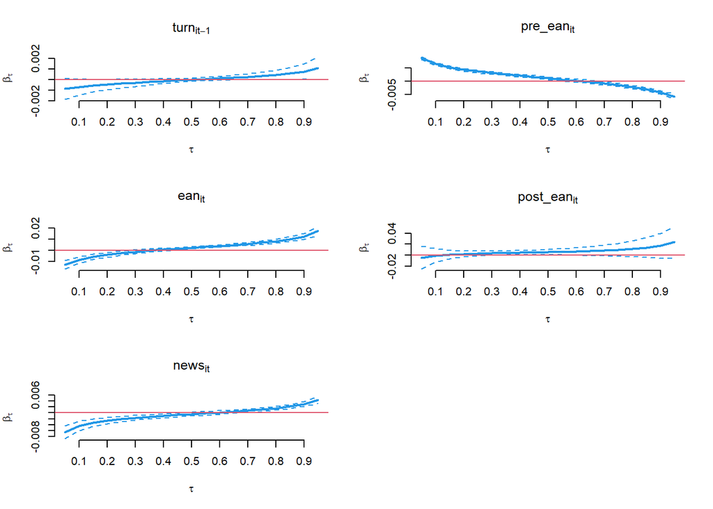

Figure 2.1: Coefficient profiles of the investor attention related variables for different $\tau$-levels

Note that the effects of $turn_{i,t-1}$, $ean_{i,t}$ and $news_{i,t}$ are negative for low expectiles and become positive for higher $\tau$-levels. For the effect of $pre\_ean_{i,t}$ the opposite holds. We explain the findings with buyer excitement (“the rumor”) on the days before the earnings announcements and seller excitement at news arrivals (“the news”) for low expectiles of return.

Now we inspect the effects related to investor perception with $95\%$-CI in Figure 2.2:

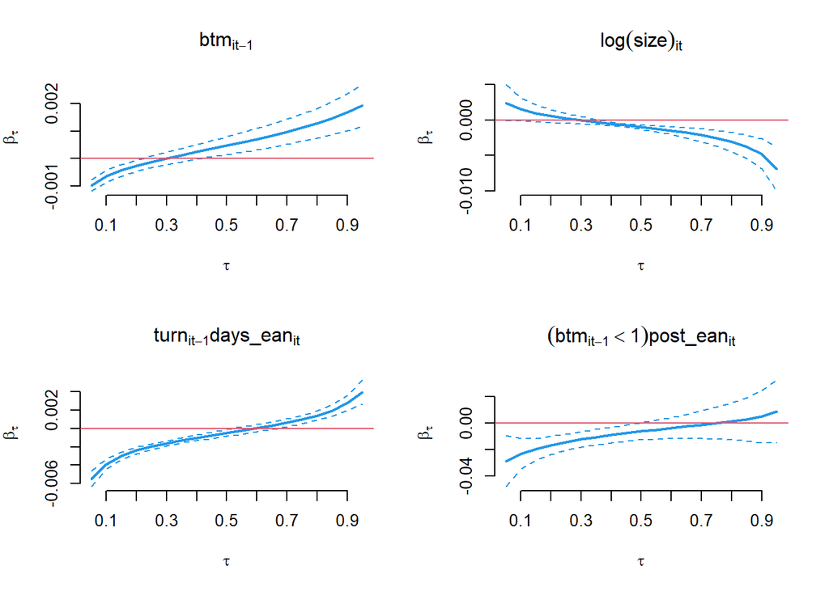

Figure 2.2: Coefficient profiles of the investor perception related variables for different $\tau$-levels

The effects of $btm_{i,t-1}$ and turnover around earnings announecements appear to be negative for low expectiles and become increasingly positive for higher $\tau$ indicating their particular importance in extreme states of the market. $\log(size)$ exhibits increasingly negative influence for higher return expectiles. According to the results, the returns of firms with small btm ratio smaller than one and low return states undergo a negative correction in the post earnings day.

In the next figure we plot the effects related to investor sentiment with $95\%$-CI in Figure 2.3:

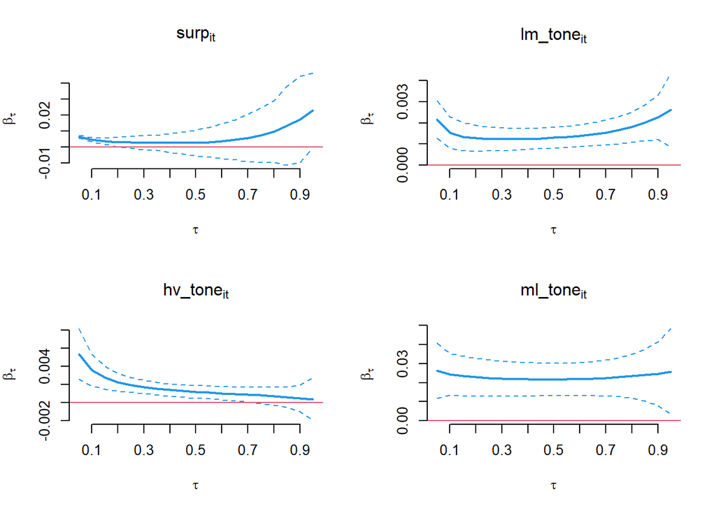

Figure 2.3: Coefficient profiles of the investor sentiment related variables for different $\tau$-levels

The effect of earnings surprises $surp_{i,t}$ is solely for low expectiles significant. Whereas the effects of $lm\_tone_{i,t}$ and $ml\_tone_{i,t}$ do not differ significantly from a constant one across expectiles, $hv\_tone_{i,t}$ seems to have an increasing impact on low return expectiles. Overall, the sentiment effects are positive, that is, the sign of the sentiment tone determines the expected direction of the conditional return reaction.

That is, in low return state also positive news can lead to a negative effect on the excess return. We explain this effect with the buyer excitement prior to earnings announcements following by seller excitement on news days for returns in lower expectiles connected to the trading strategy ‘Buy on rumor, sell on news’ for the low return state. That is, some investors tend to buy equities with low returns when they expect their growth (the ‘rumor’ part) (when they are believed to be underpriced) and sell low return stocks to ride on the hype of positive news arrivals.

# 3 Impact of investor opinion on the conditional expected shortfall of the returns

A frequently used risk measure is the $\alpha$-expected shortfall, denoted as $ES_{\alpha}$. It is connected to the quantile $q_\alpha$ of the target distribution. For the lower tail of the later this risk measure is defined as $ES_\alpha = \mathbb E(Y|Y<q_\alpha)$.

Jones (1994) shows that there is a one-to-one correspondence between quantiles and expectiles of a distribution. Based thereof, Taylor (2008) proposes to use expectiles to estimate $ES_{\alpha}$ with $\alpha\leq 0.5$ via:

$$\begin{align}
ES_{\alpha} &= \left(1+\frac{\tau}{(1-2\tau)\alpha}\right)e_{\tau} - \frac{\tau}{(1-2\tau)\alpha}e_{0.5},
\end{align}$$

where $\alpha\in(0,0.5]$ denotes the quantile level, $\tau\in(0,1)$ is the associated expectile level, and $e_{\tau}$ is the respective expectile. As Taylor (2008), the same relation holds for the conditional expected shortfall with respect to the conditional expectile.

Yao and Tong (1996) show the existence of a bijective function $\tau:(0,1)\rightarrow (0,1)$ which connects the quantile level $\alpha$ to the expectile level $\tau$ such that $q_\alpha = e_{\tau(\alpha)}$.

Thus, if the relation $\hat\tau(\alpha)$ or its estimate $\hat \tau(\alpha)$ is available, a plug-in estimator for the expected conditional shortfall based on the estimated conditional expectile analog to the autoregressive version in Taylor (2008) can be obtained:

$$\begin{align}
ES_{\alpha}(r_{i,t}|x_{i,t},z_i) &= \left(1+\frac{\hat\tau(\alpha)}{\big(1-2\hat\tau(\alpha)\big)\alpha}\right)e_{\hat\tau(\alpha)}(r_{i,t}|x_{i,t},z_i) - \frac{\hat\tau(\alpha)}{\big(1-2\hat\tau(\alpha)\big)\alpha}e_{0.5}(r_{i,t}|x_{i,t},z_i)\nonumber\\
&=\tilde \beta_{0,\alpha} + \tilde\beta_{\alpha}^\top \cdot x_{i,t} + \tilde\gamma_\alpha^\top\cdot z_i,\tag{3.1}
\end{align}$$

and $\tilde\beta_0$ and $\tilde\gamma$ are defined analogous.

For instance, in our model specification the lower quantile levels $\alpha\in\{0.01,0.05,0.1\}$ correspond to the expectile levels $\tau\in\{0.0027,0.0214,0.0533\}$ respectively.

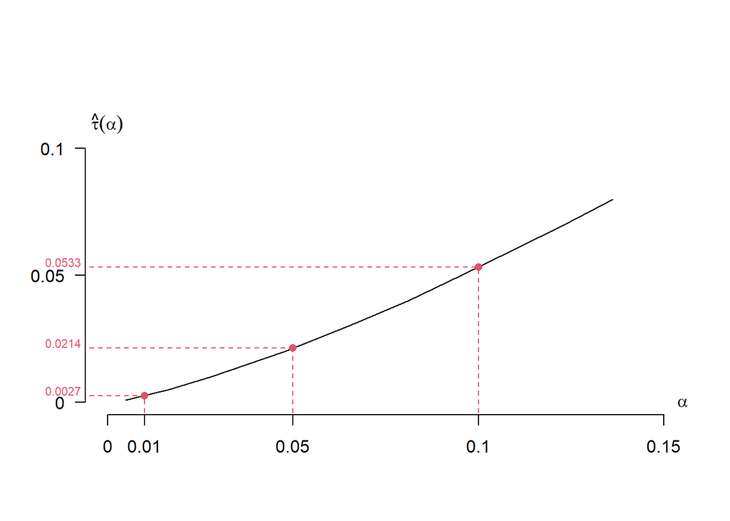

For the target $\alpha\in\{0.01,0.05,0.1\}$ we compute the resulting coefficients $\tilde\beta_\alpha$ which stand for the investor opinion effects on the conditional expected shortfall. The associated $95\%$ confidence intervals are obtained by cross-sectional and temporal bootstrap as defined in Kapetanios (2008). To preserve the possible serial dependence structure we use block bootstrap for the time-series dimension with block length of $60$.

The bootstrapping is carried out as follows. For each bootstrap draw $b=1,\ldots, B$, we, first, estimate the ER model for a fine grid of $\tau$-values in the left tail $0.001,0.0025,0.005,0.01,0.02,\ldots,0.1$. Then using the fitted conditional expectiles, we estimate the correspondence $\hat\tau^{(b)}(\alpha)$ by assigning to each $\tau$-value the proportion of observations $\alpha$ in the bootstrap sample lying below the expectile profile $\{e_{tau}(r^{(b)}_{it})\}_{i=1,t=1}^{N,T}$. By interpolating linearly between the points, we determine the needed $\tau$-levels for the target $\alpha$-levels of $0.01,0.05,0.1$. The estimated $\hat\tau(\alpha)$ with $95\%$ bootstrap confidence intervals is presented in Figure 3.2.

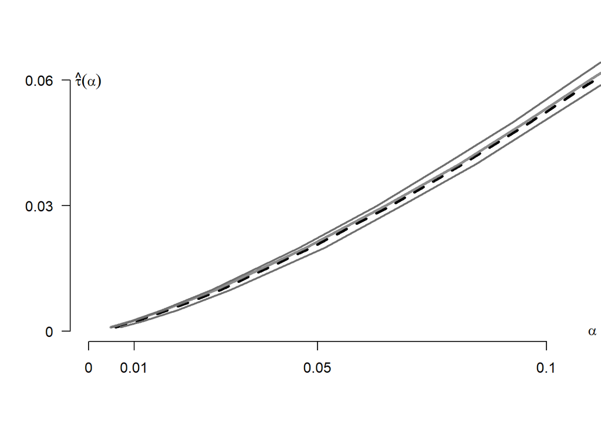

Table 3.1: The estimated coefficients $\tilde\beta_\alpha$ measuring the effects of investor opinion on the expected shortfall. The $95\%$ bootstrap confidence intervals are given in brakets.

|  | $ES_{0.01}$ | $ES_{0.05}$ | $ES_{0.1}$ |
| --- | --- | --- | --- |
| Constant | -0.1608 (-0.6485,0.0479) | -0.0779 ( -0.3651 , 0.0497 ) | -0.0711 ( -0.2725 , 0.0453 ) |
| $turn_{i,t-1}$ | -0.0033 (-0.007,0.0029) | -0.0022 ( -0.0044 , 0.0006 ) | -0.0017 ( -0.0035 , 0.0002 ) |
| $pre\_ean_{i,t}$ | **0.014 (0.006,0.0338)** | **0.0136 ( 0.0071 , 0.0276 )** | **0.0108 ( 0.0057 , 0.0216 )** |
| $ean_{i,t}$ | **-0.0682 (-0.0749,-0.0057)** | **-0.0371 ( -0.0479 , -0.0074 )** | **-0.027 ( -0.0366 , -0.0077 )** |
| $post\_ean_{i,t}$ | -0.0581 (-0.0574,0.0346) | -0.0434 ( -0.0646 , 0.0184 ) | -0.0247 ( -0.0567 , 0.0173 ) |
| $news_{i,t}$ | **-0.0048 (-0.0361,-0.0125)** | **-0.0075 ( -0.0187 , -0.009 )** | **-0.0062 ( -0.0129 , -0.0066 )** |
| $\log(size_{i,t})$ | 0.0035 (-0.0048,0.0229) | 0.0009 ( -0.0032 , 0.013 ) | 0.001 ( -0.0029 , 0.0095 ) |
| $btm_{i,t-1}$ | -0.0008 (-0.0213,0.0133) | -0.0014 ( -0.01 , 0.0054 ) | -0.0013 ( -0.0073 , 0.0036 ) |
| $turn_{i,t-1}*days\_ean_{i,t}$ | **-0.0072 (-0.026,-0.0012)** | **-0.009 ( -0.0206 , -0.0034 )** | **-0.0068 ( -0.0163 , -0.0031 )** |
| $(btm_{i,t-1}\leq 1)*post\_ean_{i,t}$ | **-0.0258 (-0.1313,-0.0064)** | -0.0128 ( -0.0911 , 0.0055 ) | -0.0196 ( -0.0718 , 0.0068 ) |
| $supr_{i,t}$ | -0.1634 (-0.1676,0.2529) | -0.1231 ( -0.1256 , 0.2449 ) | -0.0928 ( -0.0869 , 0.1897 ) |
| $lm\_tone_{i,t}$ | 0.0129 (-0.0042,0.0201) | 0.0037 ( -0.0011 , 0.0086 ) | 0.0021 ( -0.0008 , 0.0056 ) |
| $hv\_tone_{i,t}$ | -0.0107 (-0.005,0.0419) | **0.0037 ( 0.0023 , 0.0199 )** | **0.0031 ( 0.0012 , 0.0138 )** |
| $ml\_tone_{i,t}$ | 0.003 (-0.0607,0.0853) | 0.0123 ( -0.0171 , 0.068 ) | 0.0193 ( -0.0041 , 0.0583 ) |

For $\alpha = 0.01,0.05$ and $0.1$ we confirm significant effects of $pre\_ean$, $ean$, $news$, turnover around earnings announcement days $turn\cdot days\_ean$ and the post earnings announcements effect of btm ratio smaller than one $(btm\leq 1)\cdot post\_ean$ for $\alpha=0.01$. Neither $lm\_tone$ nor $ml\_tone$ show significant impact. However, for $hv\_tone$ we find a significant effect for $\alpha=0.05$ and $0.1$.

As in the case of conditional expectile model, earnings announcements and shares turnover around earnings announcements exhibit significant negative effects on the conditional expected shortfall. Also, that the mentioned “buy on rumor, sell on news” effect (positive coefficient estimate for $pre\_ean$ and negative for $news$) persists in the conditional expected shortfall as well making it risk management relevant.

# 4 Conclusion

We analyzed the distributional effects of investor opinion on asset returns based on a panel of NASDAQ excess returns for the time period of April 2015 - August 2019. We adopt the information flow structure of Su, Qu, and Kang (2021) where investor opinion comprises such channels as investor attention, perception and sentiment. We chose the proxies for each of the channel based on the previous studies and used them as covariates in an expectile regression model introduced by Newey and Powell (1987) with excess return as response to assess the distributional effects beyond the conditional mean regression and without imposing any assumptions on the response distribution. The majority of the estimated effects depends on the expectile level or “extremeness” $\tau$ in a nonlinear way and the associated estimates change sign when moving from the left to the right tail or vice versa of the conditional response distribution. Particularly interesting appears the “buy on rumor, sell on news” effect for low expectiles fetching a positive influence of days before the earnings announcements following by downwards correction on news events (including the earnings announcements) regardless to their polarity. Moreover, the same significant effect is found in the conditional expected shortfall model, which we obtained by plugging in our conditional expectile formulation in the expected-shortfall-expectile relation derived by Taylor (2008). Our findings are thus have important implications for risk management assessment of investor opinion channels.

# 5 References

Al-Nasseri, Alya, Faek Menla Ali, and Allan Tucker. 2021. “Investor Sentiment and the Dispersion of Stock Returns: Evidence Based on the Social Network of Investors.” *International Review of Financial Analysis* 78: 101910. https://doi.org/https://doi.org/10.1016/j.irfa.2021.101910.

Antweiler, Werner, and Murray Z. Frank. 2004. “Is All That Talk Just Noise? The Information Content of Internet Stock Message Boards.” *The Journal of Finance* 59 (3): 1259–94. https://doi.org/https://doi.org/10.1111/j.1540-6261.2004.00662.x.

Audrino, Francesco, Fabio Sigrist, and Daniele Ballinari. 2020. “The Impact of Sentiment and Attention Measures on Stock Market Volatility.” *International Journal of Forecasting* 36 (2): 334–57. https://doi.org/https://doi.org/10.1016/j.ijforecast.2019.05.010.

Barry, Amadou, Karim Oualkacha, and Arthur Charpentier. 2022. “A New GEE Method to Account for Heteroscedasticity Using Asymmetric Least-Square Regressions.” *Journal of Applied Statistics* 49 (14): 3564–90. https://doi.org/10.1080/02664763.2021.1957789.

Berkman, Henk, Valentin Dimitrov, Prem C. Jain, Paul D. Koch, and Sheri Tice. 2009. “Sell on the News: Differences of Opinion, Short-Sales Constraints, and Returns Around Earnings Announcements.” *Journal of Financial Economics* 92 (3): 376–99. https://doi.org/https://doi.org/10.1016/j.jfineco.2008.04.009.

Billings, Bruce K., and Richard M. Morton. 2001. “Book-to-Market Components, Future Security Returns, and Errors in Expected Future Earnings.” *Journal of Accounting Research* 39 (2): 197–219. http://www.jstor.org/stable/2672953.

Campbell, John Y., and Ludger Hentschel. 1992. “No News Is Good News: An Asymmetric Model of Changing Volatility in Stock Returns.” *Journal of Financial Economics* 31 (3): 281–318. https://doi.org/https://doi.org/10.1016/0304-405X(92)90037-X.

Cao, H. Henry, Joshua D. Coval, and David Hirshleifer. 2002. “Sidelined Investors, Trading-Generated News, and Security Returns.” *The Review of Financial Studies* 15 (2): 615–48. https://doi.org/10.1093/rfs/15.2.615.

Das, Sanjiv R., and Mike Y. Chen. 2007. “Yahoo! For Amazon: Sentiment Extraction from Small Talk on the Web.” *Management Science* 53 (9): 1375–88. https://doi.org/10.1287/mnsc.1070.0704.

Diogo Barry, Amadou, Arthur Charpentier, and Karim Oualkacha. 2016. “Quantile and Expectile Regression for random effects model.” https://hal.archives-ouvertes.fr/hal-01421752.

Donnelly, Ray. 2014. “The Book-to-Market Ratio, Optimism and Valuation.” *Journal of Behavioral and Experimental Finance* 4: 14–24. https://doi.org/https://doi.org/10.1016/j.jbef.2014.10.002.

ENGELBERG, JOSEPH, R. DAVID MCLEAN, and JEFFREY PONTIFF. 2018. “Anomalies and News.” *The Journal of Finance* 73 (5): 1971–2001. https://doi.org/https://doi.org/10.1111/jofi.12718.

Fama, EUGENE F., and KENNETH R. French. 1992. “The Cross-Section of Expected Stock Returns.” *The Journal of Finance* 47 (2): 427–65. https://doi.org/https://doi.org/10.1111/j.1540-6261.1992.tb04398.x.

Fang, Hao, Chien-Ping Chung, Yang-Cheng Lu, Yen-Hsien Lee, and Wen-Hao Wang. 2021. “The Impacts of Investors’ Sentiments on Stock Returns Using Fintech Approaches.” *International Review of Financial Analysis* 77: 101858. https://doi.org/https://doi.org/10.1016/j.irfa.2021.101858.

Friend, Irwin, and Larry H. P. Lang. 1988. “The Size Effect on Stock Returns: Is It Simply a Risk Effect Not Adequately Reflected by the Usual Measures?” *Journal of Banking & Finance* 12 (1): 13–30. https://doi.org/https://doi.org/10.1016/0378-4266(88)90047-7.

Hagenau, Michael, Michael Liebmann, and Dirk Neumann. 2013. “Automated News Reading: Stock Price Prediction Based on Financial News Using Context-Capturing Features.” *Decision Support Systems* 55 (3): 685–97. https://doi.org/https://doi.org/10.1016/j.dss.2013.02.006.

Jegadeesh, Narasimhan, and Di Wu. 2013. “Word Power: A New Approach for Content Analysis.” *Journal of Financial Economics* 110 (3): 712–29. https://doi.org/https://doi.org/10.1016/j.jfineco.2013.08.018.

Jones, M. C. 1994. “Expectiles and m-Quantiles Are Quantiles.” *Statistics & Probability Letters* 20 (2): 149–53. https://doi.org/https://doi.org/10.1016/0167-7152(94)90031-0.

Kalev, Petko S., Wai-Man Liu, Peter K. Pham, and Elvis Jarnecic. 2004. “Public Information Arrival and Volatility of Intraday Stock Returns.” *Journal of Banking & Finance* 28 (6): 1441–67. https://doi.org/https://doi.org/10.1016/S0378-4266(03)00126-2.

Kapetanios, G. 2008. “A bootstrap procedure for panel data sets with many cross‐sectional units.” *The Econometrics Journal* 11 (2): 377–95. https://doi.org/10.1111/j.1368-423X.2008.00243.x.

Kim, Soon-Ho, and Dongcheol Kim. 2014. “Investor Sentiment from Internet Message Postings and the Predictability of Stock Returns.” *Journal of Economic Behavior & Organization* 107: 708–29. https://doi.org/https://doi.org/10.1016/j.jebo.2014.04.015.

Kneib, Thomas. 2013. “Beyond Mean Regression.” *Statistical Modelling* 13 (4): 275–303. https://doi.org/10.1177/1471082X13494159.

Koenker, Roger, and Gilbert Bassett. 1978. “Regression Quantiles.” *Econometrica* 46 (1): 33–50. http://www.jstor.org/stable/1913643.

Kothari, S. P., and Jay Shanken. 1997. “Book-to-Market, Dividend Yield, and Expected Market Returns: A Time-Series Analysis.” *Journal of Financial Economics* 44 (2): 169–203. https://doi.org/https://doi.org/10.1016/S0304-405X(97)00002-0.

Loh, Roger K. 2010. “Investor Inattention and the Underreaction to Stock Recommendations.” *Financial Management* 39 (3): 1223–51. http://www.jstor.org/stable/40963541.

LOUGHRAN, TIM, and BILL MCDONALD. 2011. “When Is a Liability Not a Liability? Textual Analysis, Dictionaries, and 10-Ks.” *The Journal of Finance* 66 (1): 35–65. https://doi.org/https://doi.org/10.1111/j.1540-6261.2010.01625.x.

Luss, Ronny, and Alexandre D’Aspremont. 2012. “Predicting Abnormal Returns from News Using Text Classification.” *Quantitative Finance* 15 (6): 999–1012. https://doi.org/10.1080/14697688.2012.672762.

Ma, Chaoqun, Shisong Xiao, and Zonggang Ma. 2018. “Investor Sentiment and the Prediction of Stock Returns: A Quantile Regression Approach.” *Applied Economics* 50 (50): 5401–15. https://doi.org/10.1080/00036846.2018.1486993.

Maheu, John M., and Thomas H. McCurdy. 2004. “News Arrival, Jump Dynamics, and Volatility Components for Individual Stock Returns.” *The Journal of Finance* 59 (2): 755–93. https://doi.org/https://doi.org/10.1111/j.1540-6261.2004.00648.x.

Newey, Whitney K., and James L. Powell. 1987. “Asymmetric Least Squares Estimation and Testing.” *Econometrica* 55 (4): 819–47. http://www.jstor.org/stable/1911031.

Nguyen, Thien Hai, Kiyoaki Shirai, and Julien Velcin. 2015. “Sentiment Analysis on Social Media for Stock Movement Prediction.” *Expert Systems with Applications* 42 (24): 9603–11. https://doi.org/https://doi.org/10.1016/j.eswa.2015.07.052.

Ni, Zhong-Xin, Da-Zhong Wang, and Wen-Jun Xue. 2015. “Investor Sentiment and Its Nonlinear Effect on Stock Returns—New Evidence from the Chinese Stock Market Based on Panel Quantile Regression Model.” *Economic Modelling* 50: 266–74. https://doi.org/https://doi.org/10.1016/j.econmod.2015.07.007.

Peasnell, K. V. 1982. “SOME FORMAL CONNECTIONS BETWEEN ECONOMIC VALUES AND YIELDS AND ACCOUNTING NUMBERS.” *Journal of Business Finance & Accounting* 9 (3): 361–81. https://doi.org/https://doi.org/10.1111/j.1468-5957.1982.tb01001.x.

Pontiff, Jeffrey, and Lawrence D. Schall. 1998. “Book-to-Market Ratios as Predictors of Market returns1This Paper Has Benefited from Comments from Workshop Participants at Arizona State University, University of Washington, and the Western Finance Association Meetings, as Well as Hendrik Bessembinder, Gary Biddle, Michael Brennan, j.b. Chay, Roger Edelen, Eugene Fama (the Referee), Wayne Ferson, Mark Huson, s.p. Kothari, Paul Malatesta, Eric Noreen, Charles Nelson, Vance Roley, Andrew Siegel, Jerold Warner, and Simon Wheatley. We Would Also Like to Thank David Myers and Denny Stephenus for Research Assistance, and Kenneth French for Providing Some of the Data Used in This Study.1.” *Journal of Financial Economics* 49 (2): 141–60. https://doi.org/https://doi.org/10.1016/S0304-405X(98)00020-8.

Sarkar, ASANI, and ROBERT A. Schwarz. 2009. “Market Sidedness: Insights into Motives for Trade Initiation.” *The Journal of Finance* 64 (1): 375–423. https://doi.org/https://doi.org/10.1111/j.1540-6261.2008.01437.x.

Shang, Zilu, Chris Brooks, and Rachel McCloy. 2014. “Are Investors Guided by the News Disclosed by Companies or by Journalists?” *Journal of Behavioral and Experimental Finance* 1: 45–60. https://doi.org/https://doi.org/10.1016/j.jbef.2014.01.003.

Su, Yaya, Yi Qu, and Yuxuan Kang. 2021. “Online Public Opinion and Asset Prices: A Literature Review.” *Data Science in Finance and Economics* 1 (1): 60–76. https://doi.org/10.3934/DSFE.2021004.

Taylor, James W. 2008. “Estimating Value at Risk and Expected Shortfall Using Expectiles.” *Journal of Financial Econometrics* 6 (2): 231–52. https://doi.org/10.1093/jjfinec/nbn001.

Waltrup, Linda Schulze, Fabian Sobotka, Thomas Kneib, and Göran Kauermann. 2015. “Expectile and Quantile Regression—David and Goliath?” *Statistical Modelling* 15 (5): 433–56. https://doi.org/10.1177/1471082X14561155.

Yao, Qiwli, and Howell Tong. 1996. “Asymmetric Least Squares Regression Estimation: A Nonparametric Approach.” *Journal of Nonparametric Statistics* 6 (2-3): 273–92. https://doi.org/10.1080/10485259608832675.

Zeileis, Achim, Susanne Köll, and Nathaniel Graham. 2020. “Various Versatile Variances: An Object-Oriented Implementation of Clustered Covariances in r.” *Journal of Statistical Software* 95 (1): 1–36. https://doi.org/10.18637/jss.v095.i01.

[^1]: Hochschule für Wirtschaft und Recht Berlin; osipenko@hwr-berlin.de
[^2]: Humboldt-Universität zu Berlin